# Predicting London House prices with Ensemble algorithms

Francesco Nicolí

2023-09-24

# Introduction and learning objectives

The purpose of this exercise is to build an estimation engine to guide investment decisions in London house market. You will first build machine learning algorithms (and tune them) to estimate the house prices given variety of information about each property. Then, using your algorithm, you will choose 200 houses to invest in out of about 2000 houses on the market at the moment.

**Learning objectives**

1. Using different data mining algorithms for prediction.
2. Dealing with large data sets
3. Tuning data mining algorithms
4. Interpreting data mining algorithms and deducing importance of variables
5. Using results of data mining algorithms to make business decisions

# Load data

There are two sets of data, i) training data that has the actual prices ii) out of sample data that has the asking prices. Load both data sets.

Make sure you understand what information each column contains. Note that not all information provided might be useful in predicting house prices, but do not make any assumptions before you decide what information you use in your prediction algorithms.

```r
#read in the data

london_house_prices_2019_training<-fread("C:/Users/optif/OneDrive/Desktop/academics/applied_statistics/Francesco_repository_1/data/training_data_assignment_with_prices.csv")
london_house_prices_2019_out_of_sample<-read.csv("C:/Users/optif/OneDrive/Desktop/academics/applied_statistics/Francesco_repository_1/data/test_data_assignment.csv")

#fix data types in both data sets

#fix dates
london_house_prices_2019_training <- london_house_prices_2019_training %>% mutate(date=as.Date(date))
london_house_prices_2019_out_of_sample<-london_house_prices_2019_out_of_sample %>% mutate(date=as.Date(date))
#change characters to factors
london_house_prices_2019_training <- london_house_prices_2019_training %>% mutate_if(is.character,as.factor)
london_house_prices_2019_out_of_sample<-london_house_prices_2019_out_of_sample %>% mutate_if(is.character,as.factor)

#take a quick look at what's in the data
str(london_house_prices_2019_training)
```

```
## Classes 'data.table' and 'data.frame':   13998 obs. of  37 variables:
##  $ ID                          : int  2 3 4 5 7 8 9 10 11 12 ...
##  $ date                        : Date, format: "0001-11-20" "0008-08-20" ...
##  $ postcode                    : Factor w/ 12635 levels "BR1 1AB","BR1 1LR",..: 10897 11027 11264 2031 11241 11066 421 9594 9444 873 ...
##  $ property_type               : Factor w/ 4 levels "D","F","S","T": 2 2 3 2 3 2 1 4 4 2 ...
##  $ whether_old_or_new          : Factor w/ 2 levels "N","Y": 1 1 1 1 1 1 1 1 1 1 ...
##  $ freehold_or_leasehold       : Factor w/ 2 levels "F","L": 2 2 1 2 1 2 1 1 1 2 ...
##  $ address1                    : Factor w/ 2825 levels "01-Feb","01-Mar",..: 2503 791 258 788 571 239 269 422 13 278 ...
##  $ address2                    : Factor w/ 434 levels "1","10","101",..: 372 NA NA NA NA NA NA NA NA NA ...
##  $ address3                    : Factor w/ 8543 levels "ABBERTON WALK",..: 6990 6821 3715 2492 4168 2879 3620 5251 6045 6892 ...
##  $ town                        : Factor w/ 133 levels "ABBEY WOOD","ACTON",..: NA NA NA 78 NA NA NA NA NA NA ...
##  $ local_aut                   : Factor w/ 69 levels "ASHFORD","BARKING",..: 36 46 24 36 24 46 65 36 36 17 ...
##  $ county                      : Factor w/ 33 levels "BARKING AND DAGENHAM",..: 22 27 18 25 18 27 5 27 32 8 ...
##  $ postcode_short              : Factor w/ 247 levels "BR1","BR2","BR3",..: 190 194 198 28 198 194 4 169 167 8 ...
##  $ current_energy_rating       : Factor w/ 6 levels "B","C","D","E",..: 4 3 3 4 3 2 4 3 4 2 ...
```

[output cut: 24 more lines]

```r
str(london_house_prices_2019_out_of_sample)
```

```
## 'data.frame':    1999 obs. of  37 variables:
##  $ ID                          : int  14434 12562 8866 10721 1057 1527 13961 12108 9363 1155 ...
##  $ date                        : Date, format: NA NA ...
##  $ postcode                    : logi  NA NA NA NA NA NA ...
##  $ property_type               : Factor w/ 4 levels "D","F","S","T": 1 2 2 3 4 3 2 3 2 4 ...
##  $ whether_old_or_new          : Factor w/ 2 levels "N","Y": 1 1 1 1 1 1 1 1 1 1 ...
##  $ freehold_or_leasehold       : Factor w/ 2 levels "F","L": 1 2 2 1 1 1 2 1 2 1 ...
##  $ address1                    : logi  NA NA NA NA NA NA ...
##  $ address2                    : logi  NA NA NA NA NA NA ...
##  $ address3                    : logi  NA NA NA NA NA NA ...
##  $ town                        : Factor w/ 54 levels "ACTON","ADDISCOMBE",..: NA NA NA NA NA NA NA NA NA NA ...
##  $ local_aut                   : logi  NA NA NA NA NA NA ...
##  $ county                      : logi  NA NA NA NA NA NA ...
##  $ postcode_short              : Factor w/ 221 levels "BR1","BR2","BR3",..: 82 50 37 52 214 150 159 115 175 126 ...
##  $ current_energy_rating       : Factor w/ 6 levels "B","C","D","E",..: 3 2 3 3 4 4 4 3 4 3 ...
```

[output cut: 23 more lines]

```r
#dropping columns with missing values
london_house_prices_2019_training <- london_house_prices_2019_training %>%
  select(-c(address2, town, population))

#let's do the initial split
library(rsample)
set.seed(123)
train_test_split <- initial_split(london_house_prices_2019_training, prop = 0.75) #training set contains 75% of the data
# Create the training dataset
train_data <- training(train_test_split)
test_data <- testing(train_test_split)
```

# Visualize data

Visualize and examine the data. What plots could be useful here? What do you learn from these visualizations?

```r
# Analyzing the dataset
skimr::skim(london_house_prices_2019_training)
```

Data summary

| Name | london_house_prices_2019_… |
| --- | --- |
| Number of rows | 13998 |
| Number of columns | 34 |
| Key | NULL |
| _______________________ |  |
| Column type frequency: |  |
| Date | 1 |
| factor | 16 |
| numeric | 17 |
| ________________________ |  |
| Group variables | None |

**Variable type: Date**

| skim_variable | n_missing | complete_rate | min | max | median | n_unique |
| --- | --- | --- | --- | --- | --- | --- |
| date | 0 | 1 | 0001-02-20 | 0031-10-20 | 0017-05-20 | 263 |

**Variable type: factor**

| skim_variable | n_missing | complete_rate | ordered | n_unique | top_counts |
| --- | --- | --- | --- | --- | --- |
| postcode | 0 | 1 | FALSE | 12635 | E11: 5, BR1: 4, CR0: 4, E17: 4 |
| property_type | 0 | 1 | FALSE | 4 | F: 5402, T: 4999, S: 2780, D: 817 |
| whether_old_or_new | 0 | 1 | FALSE | 2 | N: 13990, Y: 8 |
| freehold_or_leasehold | 0 | 1 | FALSE | 2 | F: 8457, L: 5541 |
| address1 | 0 | 1 | FALSE | 2825 | 3: 220, 7: 212, 4: 204, 12: 197 |
| address3 | 0 | 1 | FALSE | 8543 | LON: 25, GRE: 24, THE: 23, HIG: 21 |
| local_aut | 0 | 1 | FALSE | 69 | LON: 7512, ROM: 396, BRO: 277, CRO: 243 |
| county | 0 | 1 | FALSE | 33 | BRO: 861, CRO: 729, WAN: 702, HAV: 672 |
| postcode_short | 0 | 1 | FALSE | 247 | CR0: 243, SW1: 204, E17: 193, SW1: 187 |
| current_energy_rating | 0 | 1 | FALSE | 6 | D: 7075, C: 3488, E: 2646, B: 361 |
| windows_energy_eff | 0 | 1 | FALSE | 5 | Ave: 7819, Goo: 3244, Ver: 1698, Poo: 1231 |
| tenure | 0 | 1 | FALSE | 3 | own: 11236, ren: 2503, ren: 259 |
| nearest_station | 0 | 1 | FALSE | 592 | rom: 201, cha: 103, bex: 99, har: 96 |
| water_company | 0 | 1 | FALSE | 5 | Tha: 10471, Aff: 1577, Ess: 1154, SES: 792 |
| district | 0 | 1 | FALSE | 33 | Cro: 925, Bro: 843, Hav: 681, Bex: 603 |
| type_of_closest_station | 0 | 1 | FALSE | 3 | rai: 6512, tub: 4711, lig: 2775 |

**Variable type: numeric**

| skim_variable | n_missing | complete_rate | mean | sd | p0 | p25 | p50 | p75 | p100 | hist |
| --- | --- | --- | --- | --- | --- | --- | --- | --- | --- | --- |
| ID | 0 | 1 | 8003.94 | 4622.57 | 2.00 | 4004.50 | 8015.50 | 12018.75 | 1.5996e+04 | ▇▇▇▇▇ |
| total_floor_area | 0 | 1 | 92.55 | 45.08 | 21.00 | 64.00 | 83.00 | 108.00 | 4.8000e+02 | ▇▂▁▁▁ |
| number_habitable_rooms | 0 | 1 | 4.31 | 1.66 | 1.00 | 3.00 | 4.00 | 5.00 | 1.4000e+01 | ▆▇▁▁▁ |
| co2_emissions_current | 0 | 1 | 4.25 | 2.39 | 0.10 | 2.70 | 3.80 | 5.20 | 4.4000e+01 | ▇▁▁▁▁ |
| co2_emissions_potential | 0 | 1 | 2.22 | 1.44 | -0.50 | 1.30 | 1.80 | 2.70 | 2.0500e+01 | ▇▁▁▁▁ |
| energy_consumption_current | 0 | 1 | 262.98 | 93.42 | 12.00 | 202.00 | 249.00 | 308.00 | 1.2960e+03 | ▇▅▁▁▁ |
| energy_consumption_potential | 0 | 1 | 141.38 | 78.06 | -49.00 | 89.00 | 122.00 | 167.00 | 1.0230e+03 | ▇▂▁▁▁ |
| latitude | 0 | 1 | 51.49 | 0.08 | 51.30 | 51.43 | 51.49 | 51.56 | 5.1680e+01 | ▂▇▇▇▂ |
| longitude | 0 | 1 | -0.11 | 0.16 | -0.49 | -0.21 | -0.11 | 0.00 | 2.9000e-01 | ▂▅▇▅▂ |
| altitude | 0 | 1 | 36.57 | 26.01 | 0.00 | 16.00 | 32.00 | 51.00 | 2.3900e+02 | ▇▃▁▁▁ |
| london_zone | 0 | 1 | 3.76 | 1.43 | 1.00 | 3.00 | 4.00 | 5.00 | 7.0000e+00 | ▇▇▇▆▅ |
| average_income | 0 | 1 | 55334.70 | 8454.23 | 36000.00 | 49400.00 | 54600.00 | 60600.00 | 8.5200e+04 | ▃▇▆▂▁ |
| price | 0 | 1 | 593790.93 | 519158.10 | 77000.00 | 351000.00 | 460000.00 | 650000.00 | 1.0800e+07 | ▇▁▁▁▁ |
| num_tube_lines | 0 | 1 | 0.44 | 0.74 | 0.00 | 0.00 | 0.00 | 1.00 | 6.0000e+00 | ▇▁▁▁▁ |
| num_rail_lines | 0 | 1 | 0.58 | 0.51 | 0.00 | 0.00 | 1.00 | 1.00 | 2.0000e+00 | ▆▁▇▁▁ |
| num_light_rail_lines | 0 | 1 | 0.24 | 0.43 | 0.00 | 0.00 | 0.00 | 0.00 | 1.0000e+00 | ▇▁▁▁▂ |
| distance_to_station | 0 | 1 | 0.65 | 0.40 | 0.00 | 0.37 | 0.57 | 0.84 | 5.6100e+00 | ▇▁▁▁▁ |

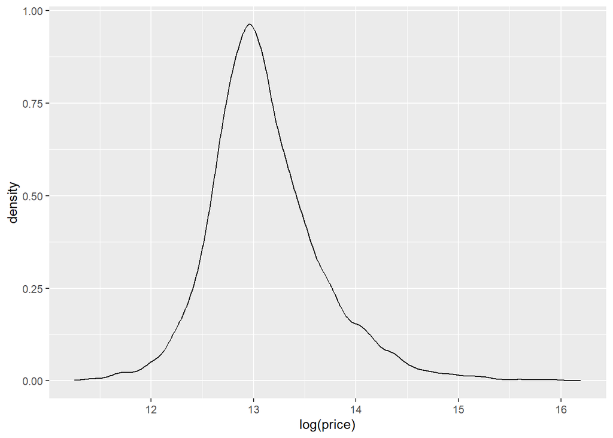

```r
# Let's first see how the response variable's distribution looks like in the
#training data
ggplot(london_house_prices_2019_training, aes(x=log(price))) +
  geom_density()
```

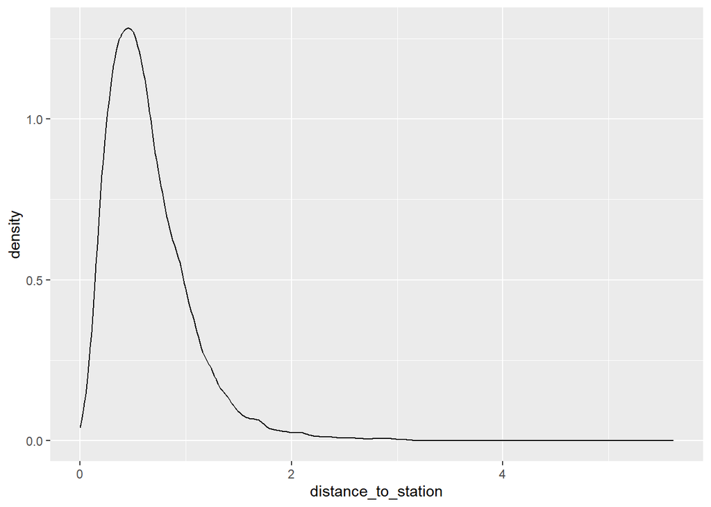

```r
# Visualizing distribution of numerical variables highly correlated with price
# distance_to_station, highly skewed variable (-0.16)
ggplot(london_house_prices_2019_training, aes(x=distance_to_station)) +
  geom_density()
```

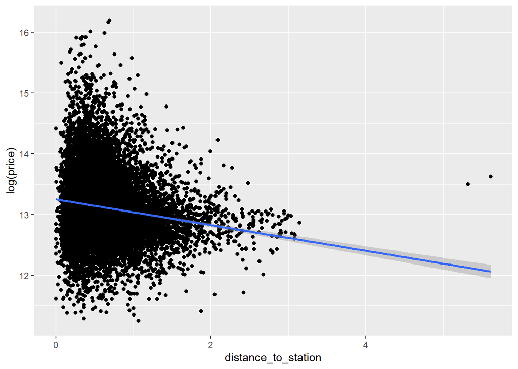

```r
ggplot(london_house_prices_2019_training, aes(x=distance_to_station, y=log(price))) +
  geom_point() + geom_smooth(method = 'lm', se = TRUE)
```

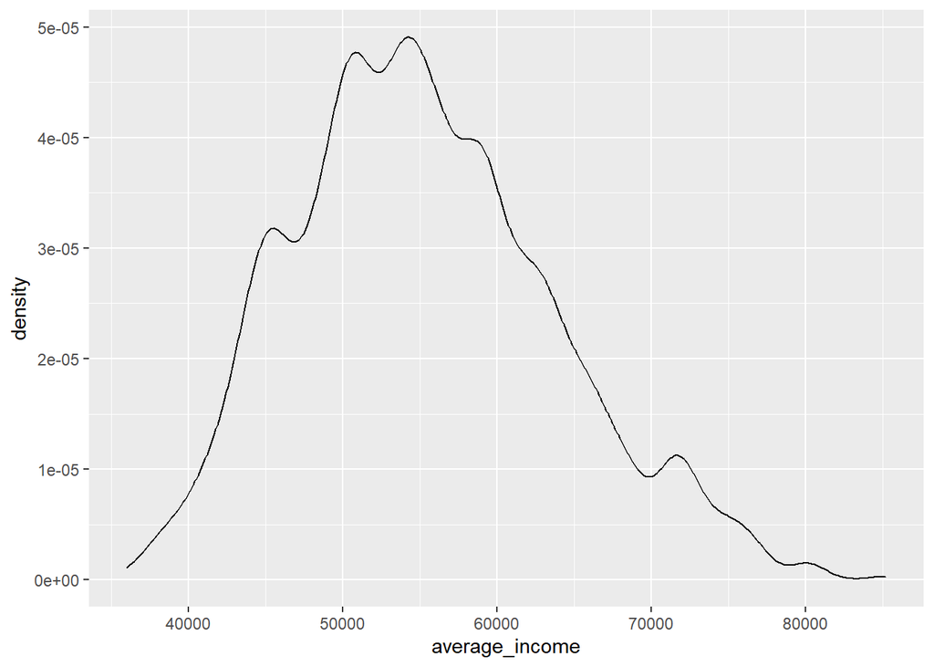

```r
# average_income (0.42)
ggplot(london_house_prices_2019_training, aes(x=average_income)) +
  geom_density()
```

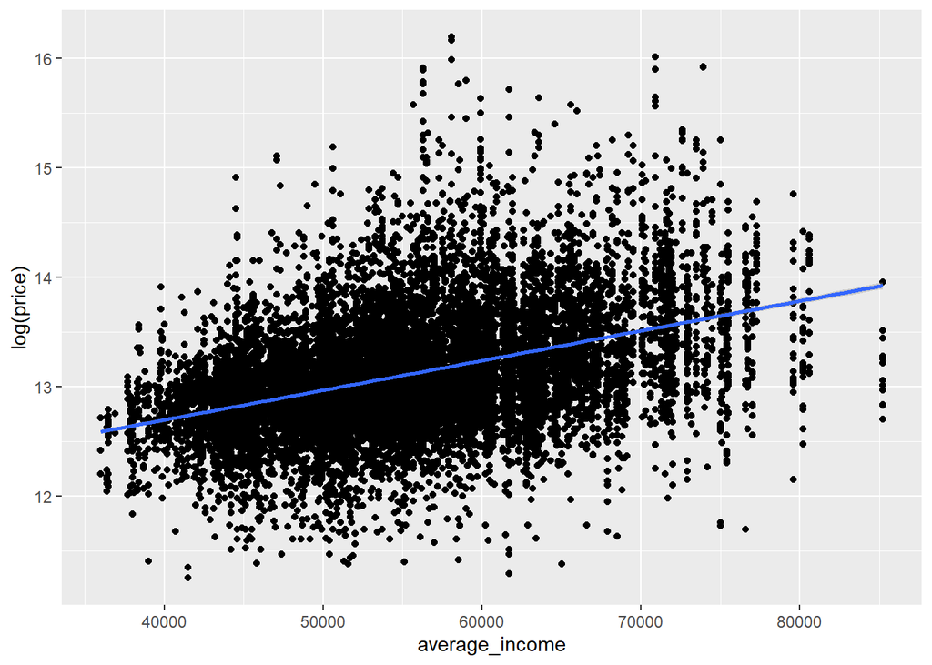

```r
ggplot(london_house_prices_2019_training, aes(x=average_income, y=log(price))) +
  geom_point() + geom_smooth(method = 'lm', se = TRUE)
```

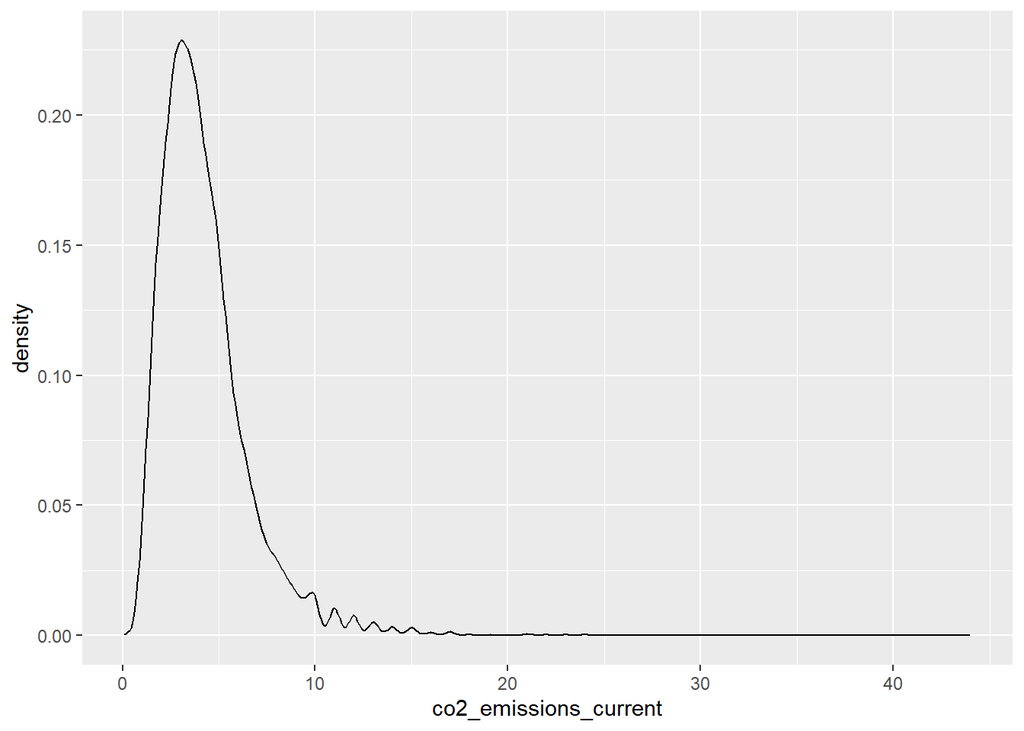

```r
# co2_emissions_current (0.58)
ggplot(london_house_prices_2019_training, aes(x=co2_emissions_current)) +
  geom_density()
```

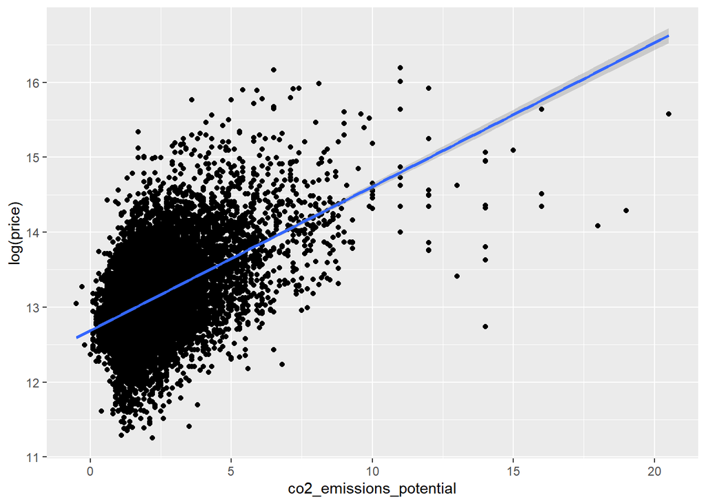

```r
ggplot(london_house_prices_2019_training, aes(x=co2_emissions_potential, y=log(price))) +
  geom_point() + geom_smooth(method = 'lm', se = TRUE)
```

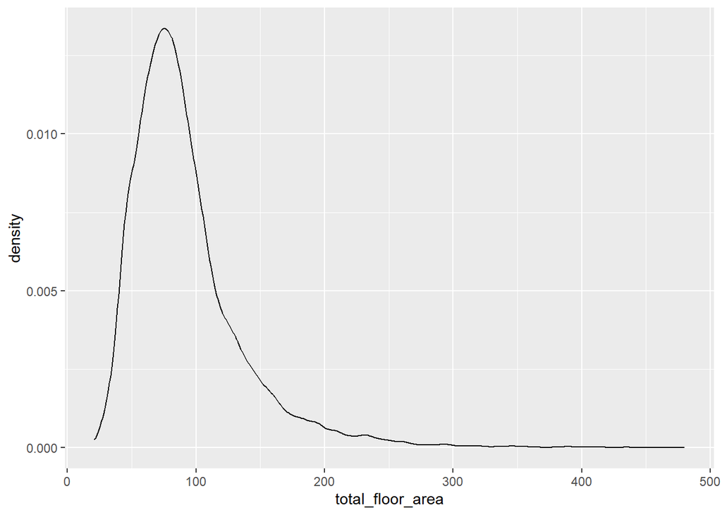

```r
# total_floor_area (0.74, highly correlated with co2_emissions_potential)
ggplot(london_house_prices_2019_training, aes(x=total_floor_area)) +
  geom_density()
```

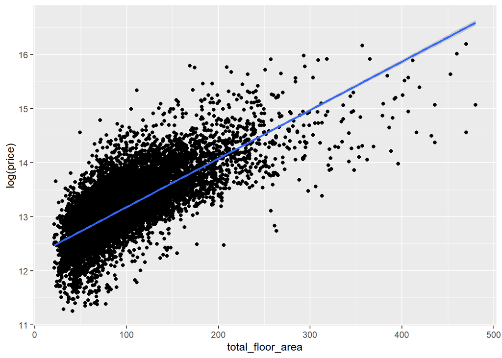

```r
ggplot(london_house_prices_2019_training, aes(x=total_floor_area, y=log(price))) +
  geom_point() + geom_smooth(method = 'lm', se = TRUE)
```

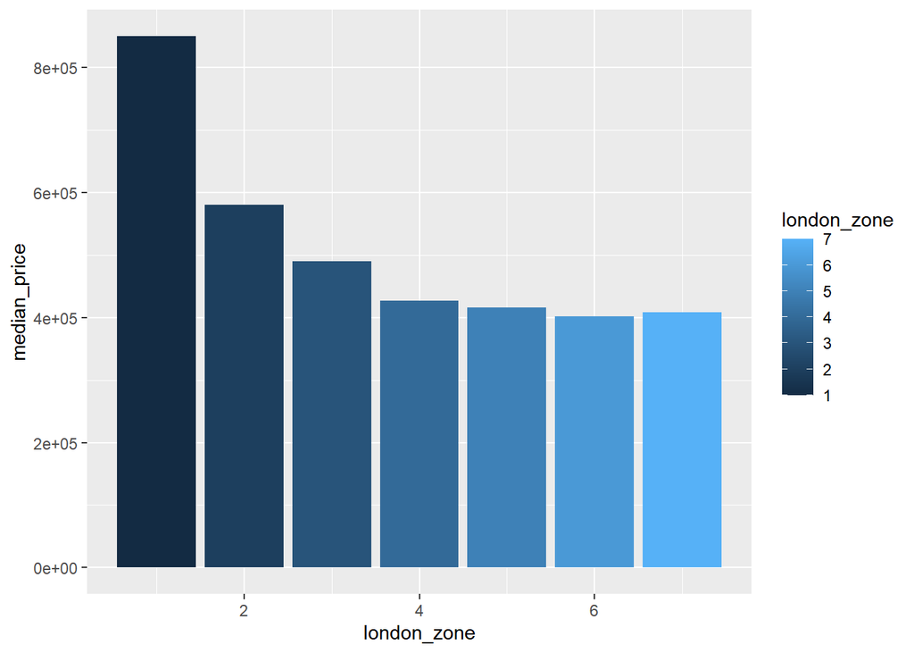

```r
# Visualizing relationship with qualitative variables
# london_zone (moderate correlation)
london_house_prices_2019_training %>%
  group_by(london_zone) %>%
  summarise(median_price = median(price)) %>%
  ggplot(aes(x=london_zone,
             y=median_price,
             fill=london_zone)) +
  geom_bar(stat = 'identity')
```

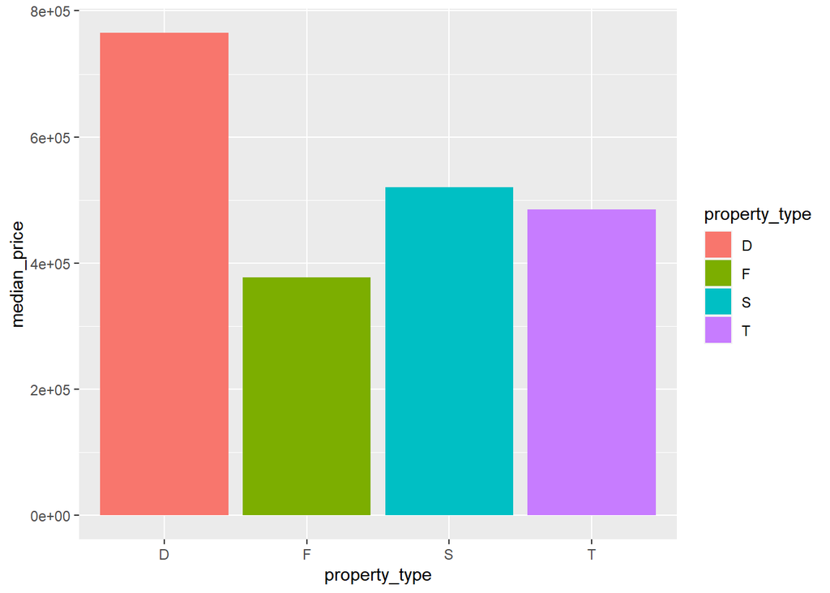

```r
# property_type (moderate correlation)
london_house_prices_2019_training %>%
  group_by(property_type) %>%
  summarise(median_price = median(price)) %>%
  ggplot(aes(x=property_type,
             y=median_price,
             fill=property_type)) +
  geom_bar(stat = 'identity')
```

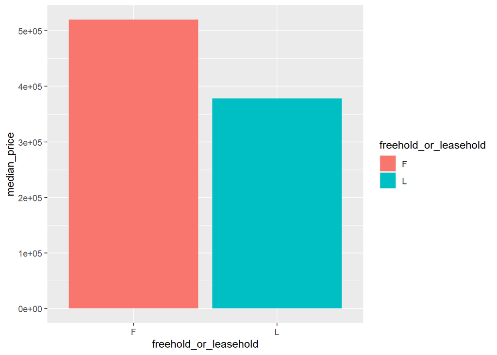

```r
# freehold_or_leasehold (moderate correlation)
london_house_prices_2019_training %>%
  group_by(freehold_or_leasehold) %>%
  summarise(median_price = median(price)) %>%
  ggplot(aes(x=freehold_or_leasehold,
             y=median_price,
             fill=freehold_or_leasehold)) +
  geom_bar(stat = 'identity')
```

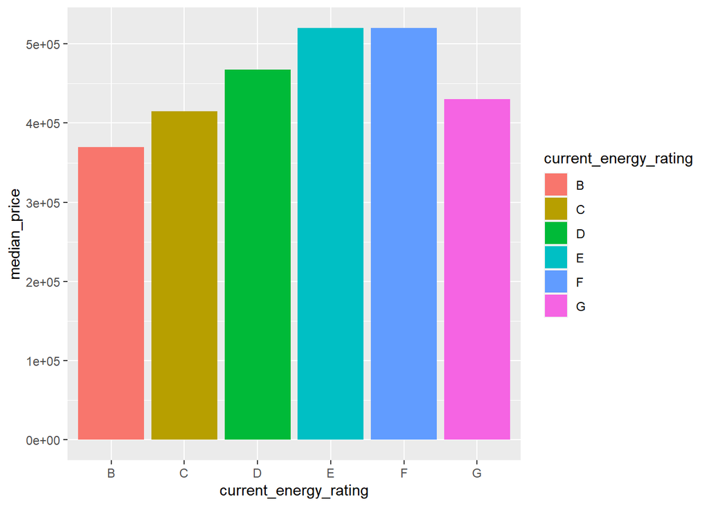

```r
# current_energy_rating (moderate correlation - high cor with co2_emissions)
london_house_prices_2019_training %>%
  group_by(current_energy_rating) %>%
  summarise(median_price = median(price)) %>%
  ggplot(aes(x=current_energy_rating,
             y=median_price,
             fill=current_energy_rating)) +
  geom_bar(stat = 'identity')
```

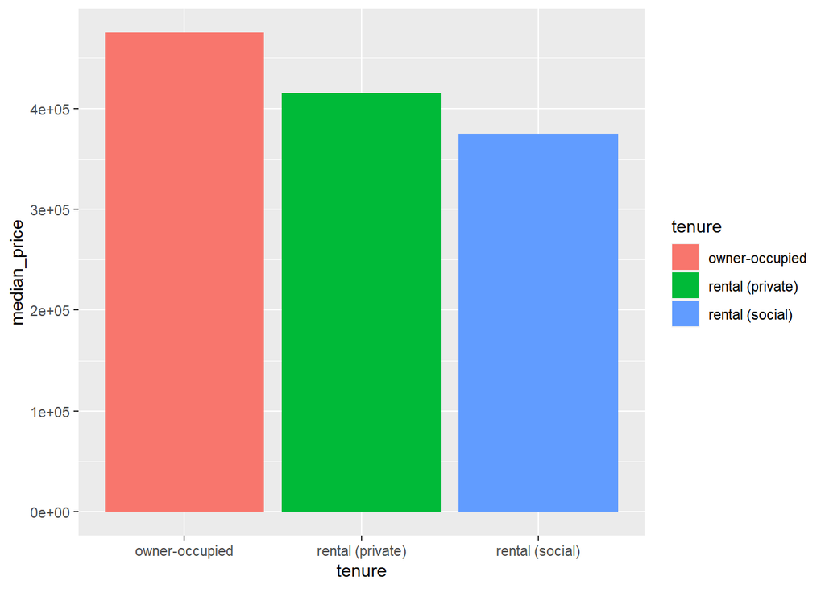

```r
# tenure (weak correlation)
london_house_prices_2019_training %>%
  group_by(tenure) %>%
  summarise(median_price = median(price)) %>%
  ggplot(aes(x=tenure,
             y=median_price,
             fill=tenure)) +
  geom_bar(stat = 'identity')
```

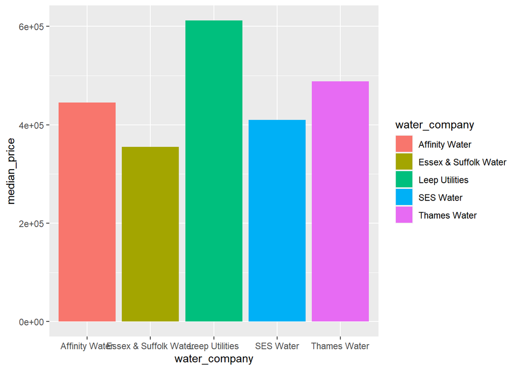

```r
# water_company (moderate to high correlation)
london_house_prices_2019_training %>%
  group_by(water_company) %>%
  summarise(median_price = median(price)) %>%
  ggplot(aes(x=water_company,
             y=median_price,
             fill=water_company)) +
  geom_bar(stat = 'identity')
```

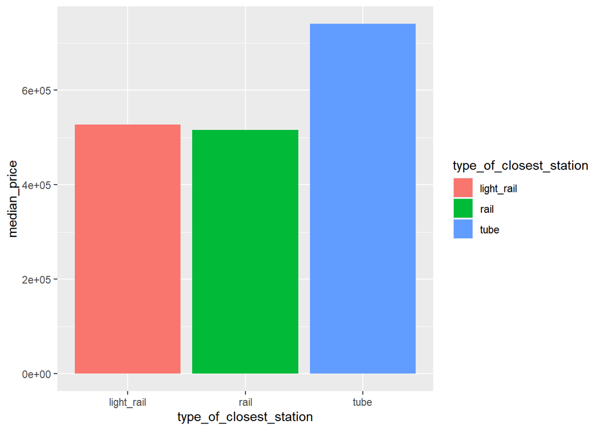

```r
# type_of_closest_station (moderate to high correlation)
london_house_prices_2019_training %>%
  group_by(type_of_closest_station) %>%
  summarise(median_price = mean(price)) %>%
  ggplot(aes(x=type_of_closest_station,
             y=median_price,
             fill=type_of_closest_station)) +
  geom_bar(stat = 'identity')
```

> First, it is important to skimr::skim() the data set in order to get a rough sense of the main features of the data: missing data, minimum, maximum, rough representation of the distribution. In addition, it is crucial to visualise the distribution of continuous variables (especially those most correlated with the output variable we are trying to predict), in order to get a sense of their skewness and correlation with the price. In fact, we do the same with categorical variables: we visualize how those variables affect the price.

> Through these visualisations, we can learn the type and magnitude of the correlation with the output variable for each input variable and choose which to include in our models accordingly.

Estimate a correlation table between prices and other continuous variables. What do you glean from the correlation table?

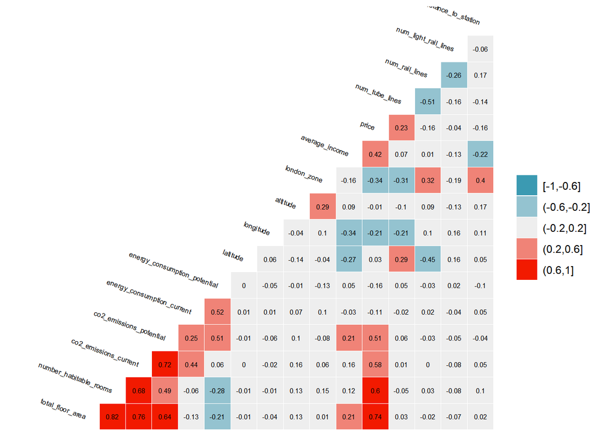

```r
# produce a correlation table using GGally::ggcor()
# this takes a while to plot

library("GGally")
london_house_prices_2019_training %>%
  select(-ID) %>% #keep Y variable last
  mutate(price = log(price)) %>%
  ggcorr(method = c("pairwise", "pearson"), layout.exp = 2,label_round=2, label = TRUE,label_size = 2,hjust = 1,nbreaks = 5,size = 2,angle = -20)
```

> It is also possible to get a sense of the correlation among regressors: the correlation table is extremely useful when it comes to assessing the potential of multicolinearity in the model, due to correlation among predictors.

# Fit a linear regression model

To help you get started I build a linear regression model below. I chose a subset of the features with no particular goal. You can (and should) add more variables and/or choose variable selection methods if you want.

```r
#Define control variables
control <- trainControl(
    method="cv",
    number=5,
    verboseIter=TRUE) #by setting this to true the model will report its progress after each estimation

set.seed(987)
#We are going to train the model on the training data and select the features
#using the stepwise selection method
lm_model <- train(
  log(price) ~ total_floor_area*district + water_company + property_type + london_zone + num_tube_lines + co2_emissions_current + number_habitable_rooms + average_income,
  train_data,
  method = "leapBackward",
  tuneGrid = data.frame(nvmax = 67:77),
  trControl = control
)
#linear check
linear <- train(
  log(price) ~ total_floor_area*district + water_company + property_type + london_zone + num_tube_lines + co2_emissions_current + number_habitable_rooms + average_income,
  train_data,
  method = "lm",
  trControl = control
)
#shows results of all models
lm_model$results
```

```
##    nvmax      RMSE  Rsquared       MAE      RMSESD RsquaredSD       MAESD
## 1     67 0.2352617 0.8180772 0.1697352 0.005958841 0.01099565 0.004305254
## 2     68 0.2352605 0.8180794 0.1697389 0.005949793 0.01096769 0.004297417
## 3     69 0.2352330 0.8181212 0.1697204 0.005970932 0.01102742 0.004316948
## 4     70 0.2352574 0.8180810 0.1697365 0.005993725 0.01107001 0.004335299
## 5     71 0.2352560 0.8180837 0.1697251 0.006014466 0.01110933 0.004341583
## 6     72 0.2352424 0.8181055 0.1697106 0.005998063 0.01109073 0.004328772
## 7     73 0.2352371 0.8181150 0.1697141 0.006005415 0.01109441 0.004332740
## 8     74 0.2357299 0.8173730 0.1698350 0.005886254 0.01054628 0.004248299
## 9     75 0.2357372 0.8173619 0.1698385 0.005900385 0.01056457 0.004250232
## 10    76 0.2357356 0.8173643 0.1698360 0.005901955 0.01056777 0.004248351
## 11    77 0.2357379 0.8173607 0.1698383 0.005902380 0.01056646 0.004248184
```

```r
#summarizes model of best fit's coefficients
coef(lm_model$finalModel, lm_model$bestTune$nvmax)
```

```
##                                     (Intercept)
##                                    1.204491e+01
##                                total_floor_area
##                                    4.967651e-03
##                                  districtBarnet
##                                    2.293667e-01
##                                  districtBexley
##                                   -9.491599e-02
##                                   districtBrent
##                                    7.688915e-02
##                                 districtBromley
##                                   -2.081570e-02
##                                  districtCamden
##                                    3.493270e-01
##                          districtCity of London
##                                   -2.436411e-01
##                                 districtCroydon
##                                    1.490183e-02
##                                  districtEaling
##                                    9.199875e-02
##                                 districtEnfield
##                                    1.682024e-01
##                               districtGreenwich
##                                   -8.866608e-02
##                                 districtHackney
##                                    1.600919e-01
##                  districtHammersmith and Fulham
##                                    2.152380e-01
##                                districtHaringey
##                                    1.817209e-01
##                                  districtHarrow
##                                    1.920113e-01
##                                districtHavering
##                                    1.487716e-01
##                              districtHillingdon
##                                    1.734553e-01
##                               districtIslington
##                                    6.526344e-02
##                  districtKensington and Chelsea
##                                    6.002370e-01
```

[output cut: 85 more lines]

```
##                                   -4.241107e-04
##   total_floor_area:districtRichmond upon Thames
##                                    7.371436e-04
##              total_floor_area:districtSouthwark
##                                    8.629220e-04
##                 total_floor_area:districtSutton
##                                   -4.306732e-04
##          total_floor_area:districtTower Hamlets
##                                    3.155071e-03
##         total_floor_area:districtWaltham Forest
##                                   -5.507034e-04
##             total_floor_area:districtWandsworth
##                                    6.387632e-04
##            total_floor_area:districtWestminster
##                                    3.592844e-03
```

```r
# we can check variable importance as well
importance <- varImp(lm_model, scale=TRUE)
plot(importance)
```

[output not shown]

## Predict the values in testing and out of sample data

Below I use the predict function to test the performance of the model in testing data and summarize the performance of the linear regression model. How can you measure the quality of your predictions?

```r
#we can predict the testing values
predictions <- predict(lm_model,test_data)

lr_results<-data.frame(RMSE = RMSE(predictions, log(test_data$price)),
                       Rsquare = R2(predictions, log(test_data$price)))

lr_results
```

```
##        RMSE   Rsquare
## 1 0.2359316 0.8038051
```

> The quality of a linear regression model can be measured by the RMSE and the Rsquare. The RMSE (Root Mean Squared Error) measures how much do the predictions of the model differ from the actual output values. The R-squared measures what percentage of the variance in the output variable is explained by the model. In orderly to properly test the quality of our predictions, it’s crucial to compute the RMSE and R2 indices on the testing data before computing them on the testing data in order to evaluate if the model tends to overfit the training data.

# Fit a tree model

Next I fit a tree model using the same subset of features. Again you can (and should) add more variables and tune the parameter of your tree to find a better fit.

Compare the performance of the linear regression model with the tree model; which one performs better? Why do you think that is the case?

```r
#Tuning the model
tree_model <- train(
  log(price) ~ total_floor_area*district + water_company + property_type + london_zone + num_tube_lines + co2_emissions_current + number_habitable_rooms + average_income,
  train_data,
  method = "rpart",
  trControl = control,
  tuneLength=20
    )
#You can view how the tree performs
tree_model$results
```

```
##             cp      RMSE  Rsquared       MAE      RMSESD  RsquaredSD
## 1  0.004063400 0.2985840 0.7066641 0.2232557 0.005306948 0.011671255
## 2  0.004518006 0.3001552 0.7035169 0.2251580 0.005432423 0.011587482
## 3  0.004784952 0.3020810 0.6997091 0.2262033 0.005047779 0.011589485
## 4  0.004938874 0.3058423 0.6921709 0.2283820 0.004195956 0.012560703
## 5  0.004973492 0.3064415 0.6908998 0.2288124 0.003870191 0.014287125
## 6  0.005084130 0.3064415 0.6908998 0.2288124 0.003870191 0.014287125
## 7  0.005212217 0.3081166 0.6875044 0.2301096 0.003609797 0.014810509
## 8  0.007300967 0.3169993 0.6691281 0.2370062 0.005785799 0.018523813
## 9  0.007577948 0.3177738 0.6675283 0.2377291 0.005037558 0.017774203
## 10 0.008029292 0.3192045 0.6644574 0.2386778 0.004436604 0.019349903
## 11 0.012030909 0.3260777 0.6501980 0.2435703 0.006911224 0.015461608
## 12 0.013219551 0.3306273 0.6401034 0.2476438 0.005328530 0.020759968
## 13 0.016257411 0.3361044 0.6283267 0.2527506 0.003128649 0.011942365
## 14 0.017730228 0.3447175 0.6090777 0.2589218 0.005784297 0.018208108
```

[output cut: 27 more lines]

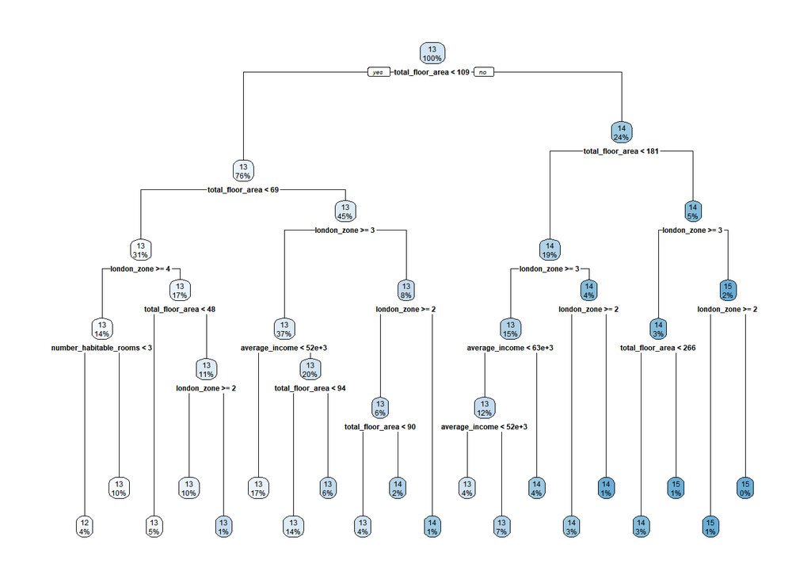

```r
#You can view the final tree
rpart.plot(tree_model$finalModel)
```

```r
# We can predict the testing values
predictions_tree <- predict(tree_model, test_data)

tree_results<-data.frame(RMSE = RMSE(predictions_tree, log(test_data$price)),
                         Rsquare = R2(predictions_tree, log(test_data$price)))

tree_results
```

```
##        RMSE   Rsquare
## 1 0.2985389 0.6863361
```

> Assuming that the response variable is the logarithm of the price (instead of the price itself), we can see that the linear regression performs significantly better than the tree algorithm. In fact, the RMSE and Rsquare for linear regression are 0.2359316 and 0.8038051 respectively, whereas the same indices for the tree model are 0.2985389 and 0.6863361 respectively.

> Tree algorithms usually perform better than linear regressions when the relationship between the predictor variables and the response variable is non-linear. However, when the relationship between response and predictor variables is at least approximately linear, the linear regression performs better. This happens because a linear increase in the predicted value - caused by a linear increase in the predictors - allows for a lower error than the one obtained when the predicted value stays the same even if predictors change, albeit the change is within a certain margin (that is the margin defined by the different splits in the model).

> In addition, in order to increase the performance of trees, we could increase the number of levels. However, this would make the model difficult to interpret.

# K-NN model

```r
set.seed(456)

#fitting the model
knn_model <- train(log(price) ~ total_floor_area*district + water_company + property_type + london_zone + num_tube_lines + co2_emissions_current + number_habitable_rooms + average_income,
                   train_data,
                   method = "knn",
                   trControl = trainControl("cv", number = 10), #use 10 fold cross validation
                   tuneLength = 10, #number of parameter values tried by function
                   preProcess = c("center", "scale"))

#showing model results
knn_model
```

```
## k-Nearest Neighbors
##
## 10498 samples
##     9 predictor
##
## Pre-processing: centered (77), scaled (77)
## Resampling: Cross-Validated (10 fold)
## Summary of sample sizes: 9448, 9448, 9447, 9448, 9447, 9448, ...
## Resampling results across tuning parameters:
##
##   k   RMSE       Rsquared   MAE
##    5  0.2388421  0.8125294  0.1714714
##    7  0.2366758  0.8164228  0.1698135
##    9  0.2368724  0.8167052  0.1698067
##   11  0.2378116  0.8161182  0.1705507
##   13  0.2394033  0.8146386  0.1714863
##   15  0.2403155  0.8141267  0.1723213
##   17  0.2413889  0.8133650  0.1731031
##   19  0.2428798  0.8119086  0.1742837
##   21  0.2445400  0.8103069  0.1754764
##   23  0.2461251  0.8087017  0.1766335
##
## RMSE was used to select the optimal model using the smallest value.
## The final value used for the model was k = 7.
```

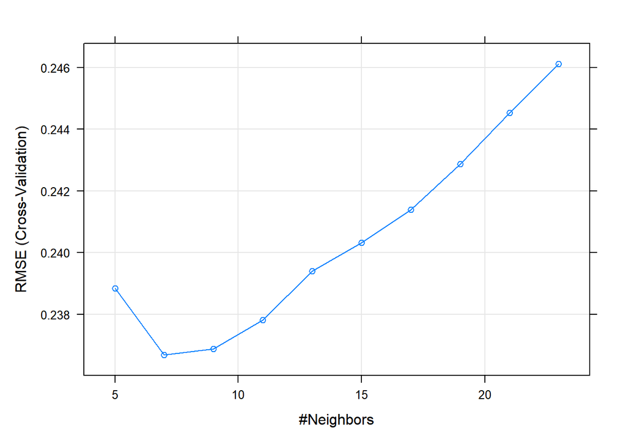

```r
plot(knn_model)
```

```r
#visualising the importance of each variable in knn_model
importance_knn <- varImp(knn_model, scale=TRUE)
plot(importance_knn)
```

[output not shown]

```r
#fit knn with expand.grid including more neighbors
knnGrid <-  expand.grid(k= seq(10,100 , by = 10))

set.seed(789)

#the metric used to choose k is the default "RMSE"
knn_model2 <- train(log(price) ~ total_floor_area*district + water_company + property_type + london_zone + num_tube_lines + co2_emissions_current + number_habitable_rooms + average_income,
                    train_data,
                    preProcess = c("center", "scale"),
                    method="knn",
                    trControl=trainControl("cv", number = 10),
                    tuneGrid = knnGrid)

#display importance of variables
importance_knn2 <- varImp(knn_model2, scale=TRUE)
plot(importance_knn2)
```

[output not shown]

```r
# display results
print(knn_model2)
```

```
## k-Nearest Neighbors
##
## 10498 samples
##     9 predictor
##
## Pre-processing: centered (77), scaled (77)
## Resampling: Cross-Validated (10 fold)
## Summary of sample sizes: 9448, 9450, 9448, 9448, 9448, 9448, ...
## Resampling results across tuning parameters:
##
##   k    RMSE       Rsquared   MAE
##    10  0.2379516  0.8153323  0.1704114
##    20  0.2439534  0.8107977  0.1750199
##    30  0.2520434  0.8024197  0.1812622
##    40  0.2607034  0.7930524  0.1875375
##    50  0.2697740  0.7827341  0.1941813
##    60  0.2788550  0.7725402  0.2008258
##    70  0.2876735  0.7628933  0.2070267
##    80  0.2965973  0.7525532  0.2133565
##    90  0.3056311  0.7413333  0.2199407
##   100  0.3145729  0.7292113  0.2262295
##
## RMSE was used to select the optimal model using the smallest value.
## The final value used for the model was k = 10.
```

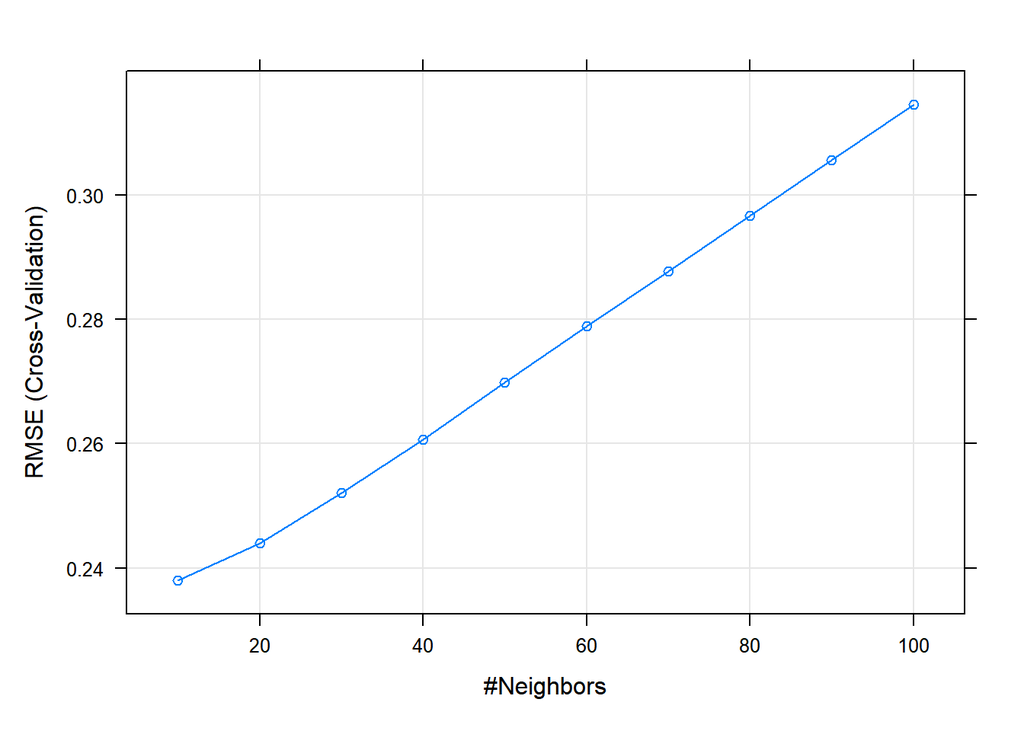

```r
# plot results
plot(knn_model2)
```

> Given that the model that gives us the lowest RMSE is knn_model (instead of the second one), we choose it as our final knn model.

```r
predictions_knn <- predict(knn_model, test_data)

knn_results<-data.frame(RMSE = RMSE(predictions_knn, log(test_data$price)),
                         Rsquare = R2(predictions_knn, log(test_data$price)))

knn_results
```

```
##        RMSE   Rsquare
## 1 0.2328593 0.8091817
```

> The K-NN model is the best-performing one: the out-of-sample RMSE is 0.2328593 and the Rsquare is 0.8091817 (out-of-sample).

# Random Forest model

```r
library(ranger)

# Define control parameters for train function below
rf_control <- trainControl(
    method="cv",
    number=5,
    savePredictions="final",
    summaryFunction=defaultSummary,
    verboseIter = TRUE
  )

# Define the tuning grid
gridRF <- data.frame(
  .mtry = c(1:7), #range of number of variables randomly selected
  .splitrule = "variance",
  .min.node.size = 5
)

# Fit random forest with ranger model
rf_model <- train(
  log(price) ~ total_floor_area + water_company + property_type + london_zone + num_tube_lines + co2_emissions_current + number_habitable_rooms + average_income,
  train_data,
  method = "ranger",
  metric="RMSE",
  trControl = rf_control,
  tuneGrid = gridRF,
  importance = "permutation" # used to estimate variable importance
)
# Print model to console
summary(rf_model)
```

```
##                           Length Class         Mode
## predictions               10498  -none-        numeric
## num.trees                     1  -none-        numeric
## num.independent.variables     1  -none-        numeric
## mtry                          1  -none-        numeric
## min.node.size                 1  -none-        numeric
## variable.importance          13  -none-        numeric
## prediction.error              1  -none-        numeric
## forest                        7  ranger.forest list
## splitrule                     1  -none-        character
## treetype                      1  -none-        character
## r.squared                     1  -none-        numeric
## call                          9  -none-        call
## importance.mode               1  -none-        character
## num.samples                   1  -none-        numeric
## replace                       1  -none-        logical
## xNames                       13  -none-        character
## problemType                   1  -none-        character
## tuneValue                     3  data.frame    list
## obsLevels                     1  -none-        logical
## param                         1  -none-        list
```

```r
print(rf_model)
```

```
## Random Forest
##
## 10498 samples
##     8 predictor
##
## No pre-processing
## Resampling: Cross-Validated (5 fold)
## Summary of sample sizes: 8397, 8399, 8398, 8399, 8399
## Resampling results across tuning parameters:
##
##   mtry  RMSE       Rsquared   MAE
##   1     0.3699940  0.7305026  0.2702040
##   2     0.2665618  0.7975526  0.1925603
##   3     0.2407698  0.8149124  0.1735071
##   4     0.2365510  0.8172689  0.1706072
##   5     0.2368788  0.8159622  0.1707941
##   6     0.2375527  0.8146504  0.1714685
##   7     0.2384971  0.8130548  0.1723382
##
## Tuning parameter 'splitrule' was held constant at a value of variance
##
## Tuning parameter 'min.node.size' was held constant at a value of 5
## RMSE was used to select the optimal model using the smallest value.
## The final values used for the model were mtry = 4, splitrule = variance
##  and min.node.size = 5.
```

```r
#printing number of trees fitted
print(rf_model$finalModel$num.trees)
```

```
## [1] 500
```

```r
#making predictions with RF model
rf_predictions <- predict(rf_model, test_data)

rf_results<-data.frame(RMSE = RMSE(rf_predictions, log(test_data$price)),
                         Rsquare = R2(rf_predictions, log(test_data$price)))

rf_results
```

```
##        RMSE   Rsquare
## 1 0.2332081 0.8085883
```

> So far, the Random Forest (ensemble method) performs roughly as well as K-NN. In fact, the out-of-sample RMSE and Rsquare obtained are 0.2332081 and 0.8085883. The best performing random forest is obtained randomly selecting 4 out of the 13 independent variables in each reiteration (to build each of the 500 trees).

# Gradient Boosting Machine model

```r
library(gbm)

# Setting control parameters for gbm train function
gbm_control <- trainControl(
  method="cv",
    number=5,
    savePredictions="final",
    summaryFunction=defaultSummary,
    verboseIter = TRUE
)

# Setting the tuning grid - trying multiple hyper parameters values for tuning
gridGBM <- expand.grid(interaction.depth = 8, n.trees = seq(200,500, by = 100),
                       shrinkage = seq(0.075, 0.2, by = 0.025),
                       n.minobsinnode = 10)

set.seed(101)

# Train for GBM
gbm_model <- train(
  log(price) ~ total_floor_area + water_company + property_type + london_zone + num_tube_lines + co2_emissions_current + number_habitable_rooms + average_income,
  train_data,
  method = "gbm",
  trControl = gbm_control,
  tuneGrid = gridGBM,
  metric = "RMSE",
  verbose = FALSE
)
# Displaying the model
print(gbm_model)
```

```
## Stochastic Gradient Boosting
##
## 10498 samples
##     8 predictor
##
## No pre-processing
## Resampling: Cross-Validated (5 fold)
## Summary of sample sizes: 8398, 8399, 8398, 8399, 8398
## Resampling results across tuning parameters:
##
##   shrinkage  n.trees  RMSE       Rsquared   MAE
##   0.075      200      0.2351774  0.8183312  0.1706719
##   0.075      300      0.2339224  0.8202809  0.1695556
##   0.075      400      0.2330008  0.8216247  0.1689262
##   0.075      500      0.2325954  0.8222599  0.1685615
##   0.100      200      0.2346403  0.8192051  0.1700379
##   0.100      300      0.2340925  0.8200435  0.1695965
##   0.100      400      0.2333986  0.8211542  0.1691031
##   0.100      500      0.2330145  0.8217405  0.1688846
##   0.125      200      0.2346126  0.8192242  0.1700827
##   0.125      300      0.2340039  0.8201701  0.1694839
##   0.125      400      0.2336320  0.8207804  0.1691335
##   0.125      500      0.2342946  0.8197523  0.1697933
##   0.150      200      0.2350029  0.8185781  0.1699909
##   0.150      300      0.2339358  0.8202132  0.1694254
##   0.150      400      0.2343338  0.8195083  0.1694177
##   0.150      500      0.2351295  0.8183929  0.1700088
##   0.175      200      0.2357566  0.8173435  0.1712915
##   0.175      300      0.2355692  0.8177320  0.1709977
##   0.175      400      0.2358351  0.8174454  0.1713712
##   0.175      500      0.2363372  0.8168208  0.1715136
##   0.200      200      0.2354116  0.8181126  0.1710719
##   0.200      300      0.2351913  0.8184074  0.1706761
##   0.200      400      0.2363896  0.8166127  0.1713111
##   0.200      500      0.2370741  0.8157362  0.1717097
##
## Tuning parameter 'interaction.depth' was held constant at a value of 8
##
## Tuning parameter 'n.minobsinnode' was held constant at a value of 10
## RMSE was used to select the optimal model using the smallest value.
## The final values used for the model were n.trees = 500, interaction.depth =
##  8, shrinkage = 0.075 and n.minobsinnode = 10.
```

```r
#making predictions with GBM model
gbm_predictions <- predict(gbm_model, test_data)

gbm_results<-data.frame(RMSE = RMSE(gbm_predictions, log(test_data$price)),
                         Rsquare = R2(gbm_predictions, log(test_data$price)))

gbm_results
```

```
##        RMSE   Rsquare
## 1 0.2313716 0.8114689
```

> The Gradient Boosting Machine is a sequential boosting algorithm. We include it in our models since we want to stack it together with a parallel ensemble algorithm and keep diversity in our stacking. The GBM model on its own already performs quite well: it is the best performing algorithm among all, with an RMSE of 0.2313716 and an Rsquare of 0.8114689 out-of-sample.

# Stacking

Use stacking to ensemble your algorithms.

> Since the tree is the worst performing method among the five built and does not add significant diversity to the stacking, we are not going to include it in the final model. The model included in the stacking are the linear model, the K-NN model, the Random Forest and the Gradient Boosting Machine.

```r
# Setting seed
set.seed(121)

# Adding all models in caretList
final_model <- caretList(
   log(price) ~ total_floor_area + district + water_company + property_type + london_zone + num_tube_lines + co2_emissions_current + number_habitable_rooms + average_income,
   data = train_data,
   metric = "RMSE",
   tuneList = list(

        # Random Forest parameters
        rft = caretModelSpec(method = "ranger",
                             tuneGrid = gridRF,
                             importance = "permutation"),

        # Gradient Boosting Machine parameters
        gbm = caretModelSpec(method = "gbm",
                             tuneGrid = gridGBM,
                             verbose = FALSE),

        # K-NN parameters
        knn = caretModelSpec(method = "knn",
                             tuneLength = 10,
                             preProcess = c("center", "scale")),

        # Linear Regression parameters
        lm = caretModelSpec(method = "leapBackward",
                            tuneGrid = data.frame(nvmax = 37:45))),

   # Train settings
   trControl = trainControl(method="cv",
                            number=5,
                            savePredictions="final",
                            summaryFunction=defaultSummary,
                            verboseIter = TRUE))
#Stacking all final models
glm_ensemble <- caretEnsemble::caretStack(final_model,
                                          method = "glm",
                                          metric = "RMSE",
                                          trControl = trainControl("cv",
                                                                   10))

#Analyzing performance of the model
glm_ensemble$error
```

```
##   parameter      RMSE  Rsquared       MAE      RMSESD  RsquaredSD       MAESD
## 1      none 0.2122337 0.8518665 0.1523655 0.006698356 0.009634936 0.004244406
```

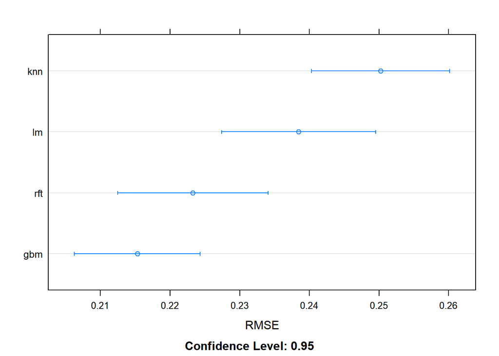

```r
fm_predictions <- predict(glm_ensemble, test_data)

resamples <- resamples(final_model)

dotplot(resamples, metric = "RMSE")
```

```r
summary(glm_ensemble)
```

```
##
## Call:
## NULL
##
## Deviance Residuals:
##      Min        1Q    Median        3Q       Max
## -1.66697  -0.10604   0.00799   0.12198   1.21471
##
## Coefficients:
##             Estimate Std. Error t value Pr(>|t|)
## (Intercept) -0.51872    0.06490  -7.992 1.46e-15 ***
## rft          0.21428    0.03202   6.692 2.31e-11 ***
## gbm          0.61147    0.02750  22.231  < 2e-16 ***
## knn          0.16675    0.01556  10.717  < 2e-16 ***
## lm           0.04723    0.01865   2.533   0.0113 *
## ---
## Signif. codes:  0 '***' 0.001 '**' 0.01 '*' 0.05 '.' 0.1 ' ' 1
##
## (Dispersion parameter for gaussian family taken to be 0.04503921)
##
##     Null deviance: 3191.1  on 10497  degrees of freedom
## Residual deviance:  472.6  on 10493  degrees of freedom
## AIC: -2747.1
##
## Number of Fisher Scoring iterations: 2
```

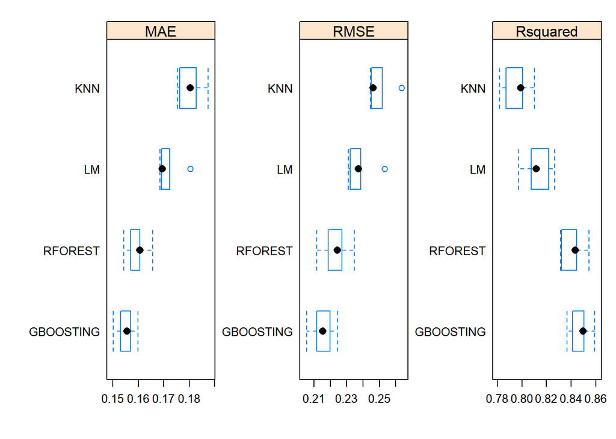

```r
# Plotting all KPI of all models used in stacking
resamples(list(
  LM=final_model$lm,
  KNN = final_model$knn,
  RFOREST = final_model$rft,
  GBOOSTING=final_model$gbm)) %>%
  bwplot(scales=list(x=list(relation='free'), y=list(relation='free')))
```

# Pick investments

In this section you should use the best algorithm you identified to choose 200 properties from the out of sample data.

> The best performing algorithm is the stacking, with an RMSE of 0.2122337 and an Rsquared of 0.8518665.

```r
numchoose=200

oos<-london_house_prices_2019_out_of_sample

#predict the value of houses
oos$predict <- exp(predict(glm_ensemble, oos))

#Choose the ones you want to invest here
oos <- oos %>%
  mutate(profit_pct = ((predict-asking_price)/asking_price)*100) %>%
  arrange(desc(profit_pct)) %>%
  mutate(buy = rep(c(1,0),c(numchoose,(nrow(oos)-numchoose))))

#output your choices. Change the name of the file to your "lastname_firstname.csv"
#write.csv(oos,"nicoli-francesco.csv")
```